# Client Report - Can You Predict That?

- Show All Code
- Hide All Code

Course DS 250

Author

[Ronaldo Monteiro]

```python
import pandas as pd
import numpy as np
from lets_plot import *
# add the additional libraries you need to import for ML here

LetsPlot.setup_html(isolated_frame=True)
from sklearn.model_selection import train_test_split
from sklearn import metrics
import seaborn as sns

from sklearn.naive_bayes import GaussianNB
from sklearn.ensemble import RandomForestClassifier
from sklearn.ensemble import GradientBoostingClassifier
from sklearn.tree import DecisionTreeClassifier
from sklearn import metrics
from IPython.display import display
```

```python
# Learn morea about Code Cells: https://quarto.org/docs/reference/cells/cells-jupyter.html

# Include and execute your code here

# import your data here using pandas and the URL

df = pd.read_csv("https://github.com/byuidatascience/data4dwellings/raw/master/data-raw/dwellings_ml/dwellings_ml.csv")
df
```

|  | parcel | abstrprd | livearea | finbsmnt | basement | yrbuilt | totunits | stories | nocars | numbdrm | ... | arcstyle_THREE-STORY | arcstyle_TRI-LEVEL | arcstyle_TRI-LEVEL WITH BASEMENT | arcstyle_TWO AND HALF-STORY | arcstyle_TWO-STORY | qualified_Q | qualified_U | status_I | status_V | before1980 |
| --- | --- | --- | --- | --- | --- | --- | --- | --- | --- | --- | --- | --- | --- | --- | --- | --- | --- | --- | --- | --- | --- |
| 0 | 00102-08-065-065 | 1130 | 1346 | 0 | 0 | 2004 | 1 | 2 | 2 | 2 | ... | 0 | 0 | 0 | 0 | 0 | 1 | 0 | 1 | 0 | 0 |
| 1 | 00102-08-073-073 | 1130 | 1249 | 0 | 0 | 2005 | 1 | 1 | 1 | 2 | ... | 0 | 0 | 0 | 0 | 0 | 1 | 0 | 1 | 0 | 0 |
| 2 | 00102-08-078-078 | 1130 | 1346 | 0 | 0 | 2005 | 1 | 2 | 1 | 2 | ... | 0 | 0 | 0 | 0 | 0 | 1 | 0 | 1 | 0 | 0 |
| 3 | 00102-08-081-081 | 1130 | 1146 | 0 | 0 | 2005 | 1 | 1 | 0 | 2 | ... | 0 | 0 | 0 | 0 | 0 | 1 | 0 | 1 | 0 | 0 |
| 4 | 00102-08-086-086 | 1130 | 1249 | 0 | 0 | 2005 | 1 | 1 | 1 | 2 | ... | 0 | 0 | 0 | 0 | 0 | 0 | 1 | 1 | 0 | 0 |
| ... | ... | ... | ... | ... | ... | ... | ... | ... | ... | ... | ... | ... | ... | ... | ... | ... | ... | ... | ... | ... | ... |
| 22908 | 09154-01-132-132 | 1130 | 955 | 0 | 0 | 1998 | 1 | 1 | 0 | 2 | ... | 0 | 0 | 0 | 0 | 0 | 1 | 0 | 1 | 0 | 0 |
| 22909 | 09154-01-133-133 | 1130 | 955 | 0 | 0 | 1998 | 1 | 1 | 0 | 2 | ... | 0 | 0 | 0 | 0 | 0 | 1 | 0 | 1 | 0 | 0 |
| 22910 | 09154-01-133-133 | 1130 | 955 | 0 | 0 | 1998 | 1 | 1 | 0 | 2 | ... | 0 | 0 | 0 | 0 | 0 | 0 | 1 | 1 | 0 | 0 |
| 22911 | 09154-01-134-134 | 1130 | 1219 | 0 | 0 | 1998 | 1 | 1 | 0 | 3 | ... | 0 | 0 | 0 | 0 | 0 | 0 | 1 | 1 | 0 | 0 |
| 22912 | 09154-01-137-137 | 1130 | 1041 | 0 | 0 | 1998 | 1 | 1 | 0 | 2 | ... | 0 | 0 | 0 | 0 | 0 | 1 | 0 | 1 | 0 | 0 |

22913 rows × 51 columns

## QUESTION|TASK 1

**Create 2-3 charts that evaluate potential relationships between the home variables and `before1980`.** Explain what you learn from the charts that could help a machine learning algorithm.

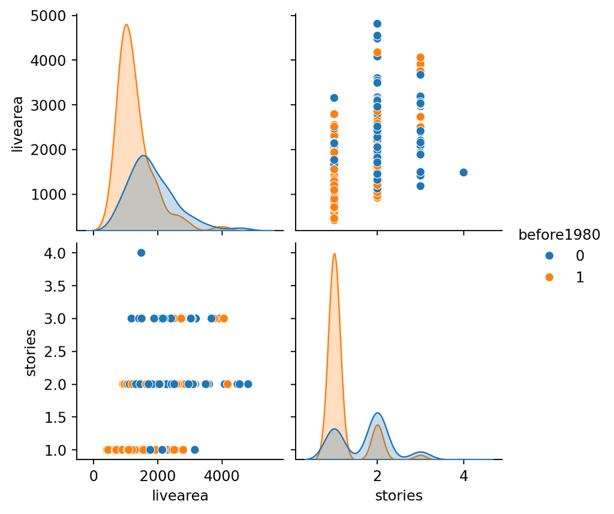

```python
# Include and execute your code here
h_subset = df.filter(['livearea', 'stories', 'finbsmnt','basement', 'before1980']).sample(500)

# List of variables to be plotted in the pairplot
vars_to_plot = ['livearea', 'stories', 'before1980']
# This line uses the seaborn library to create a pairplot of the selected variables in h_subset.
# The 'hue' parameter is set to 'before1980', which means that the data points will be colored
# based on the values in the 'before1980' column.
sns.pairplot(h_subset[vars_to_plot], hue = 'before1980')
# This line calculates the correlation matrix for the columns in h_subset excluding the 'before1980' column.
# The correlation matrix is a table showing correlation coefficients between variables.
corr = h_subset.drop(columns = 'before1980').corr()
```

## QUESTION|TASK 2

**Build a classification model labeling houses as being built “before 1980” or “during or after 1980”.** Your goal is to reach or exceed 90% accuracy. Explain your final model choice (algorithm, tuning parameters, etc) and describe what other models you tried.

```python
# Include and execute your code here
# Initialize the Random Forest classifier with a specified maximum depth
forest_DT = RandomForestClassifier(max_depth = 30)

# x = ml.filter(['livearea', 'stories', 'finbsmnt', 'numbaths', 'numbdrm', 'nocars', 'basement'])
# Feature selection: Exclude 'parcel', 'yrbuilt', and 'before1980' columns
x = df.drop(['parcel', 'yrbuilt', 'before1980'], axis = 1)
# Define the target variable
y = df.before1980
# Split the dataset into training and testing sets
x_train, x_test, y_train, y_test = train_test_split(x, y, train_size = 0.99, random_state = 5)
# Train the Random Forest classifier on the training set
forest_DT.fit(x_train, y_train)

# Make predictions on the test set
y_predicted = forest_DT.predict(x_test)
# Evaluate and print the accuracy of the classifier
print('Accuracy: ',  metrics.accuracy_score(y_test, y_predicted))
```

```
Accuracy:  0.9434782608695652
```

## QUESTION|TASK 3

**Justify your classification model by discussing the most important features selected by your model.** This discussion should include a feature importance chart and a description of the features.

```python
# Include and execute your code here
# Accessing the feature importances from the trained Random Forest classifier
forest_DT.feature_importances_

# Creating a DataFrame to organize feature names and their corresponding importances
feature_df = pd.DataFrame({'features':x.columns, 'importance':forest_DT.feature_importances_}).sort_values('importance', ascending= True)

# Visualizing feature importances using Lets_plot

(
    ggplot(feature_df, aes(x='importance', y=as_discrete('features', order_by='importance'))) +
    geom_bar(stat='identity', fill='lightgreen') +
    labs(title='Important Features (high to low)', x='Importance', y='Features') +
    theme_minimal() +
    coord_flip() +
    ggsize(800, 1500)
)
```

[output not shown]

## QUESTION|TASK 4

**Describe the quality of your classification model using 2-3 different evaluation metrics.** You also need to explain how to interpret each of the evaluation metrics you use.

```python
# Include and execute your code here
from lets_plot import *
LetsPlot.setup_html(no_js=True)

# Criar DataFrame
evaluation = pd.DataFrame({
    'Metrics': ['Accuracy', 'Recall', 'Precision'],
    'Values': [
        metrics.accuracy_score(y_test, y_predicted),
        metrics.recall_score(y_test, y_predicted),
        metrics.precision_score(y_test, y_predicted)
    ]
})

# Gráfico com Lets-Plot (estático compatível com Quarto)
(
    ggplot(evaluation, aes(x='Values', y='Metrics')) +
    geom_bar(stat='identity', fill='#87CEEB') +
    labs(title='Evaluation', x='Values', y='Metrics') +
    theme_minimal()
)
```

[figure not shown]

## STRETCH QUESTION|TASK 1

**Repeat the classification model using 3 different algorithms.** Display their Feature Importance, and Decision Matrix. Explian the differences between the models and which one you would recommend to the Client.

```python
# Include and execute your code here
```

## STRETCH QUESTION|TASK 2

**Join the `dwellings_neighborhoods_ml.csv` data to the `dwelling_ml.csv` on the `parcel` column to create a new dataset. Duplicate the code for the stretch question above and update it to use this data.** Explain the differences and if this changes the model you recomend to the Client.

```python
# Include and execute your code here
```

## STRETCH QUESTION|TASK 3

**Can you build a model that predicts the year a house was built?** Explain the model and the evaluation metrics you would use to determine if the model is good.

```python
# Include and execute your code here
```